# Machine Learning: SMS SPAM Classification (Bahasa)

Lugita Analia

2/22/2021

SMS (Short Message Service) adalah salah satu fasilitas dari teknologi GSM (Global System for Mobile) yang memungkinkan mengirim dan menerima pesan-pesan singkat berupa teks dengan kapasitas maksimal 160 karakter. Meski sudah jarang digunakan sebagai media komunikasi sehari-hari, SMS tetap menjadi media penting untuk beberapa orang. Selain itu proses verifikasi hal penting seringkali dilakukan melalui SMS. Namun tidak dapat dipungkiri bahwa SMS yang kita terima bukanlah sebuah pesan yang penting atau bisa disebut sebagai (SPAM). Pada project kali ini akan dibuat sebuah model untuk memprediksi sebuah SMS apakah *SPAM* atau *HAM* dengan menggunakan dua jenis model yaitu *Naive Bayes* dan *Random Forest*.

# 1 Setup & Library

## 1.2 Library

Berikut ini serangkaian library yang digunakan untuk proses pemodelan.

```r
# library
library(dplyr)
library(lubridate)
library(tm)
library(textclean)
library(devtools)
library(katadasaR)
library(tokenizers)
library(wordcloud)
library(stopwords)
library(e1071) #Naive Bayes
library(caret) #Confussion Matrix
library(ROCR)
library(lime)
library(ggplot2)
library(tidyr)
library(tibble)
```

# 2 Data Pre-Processing

## 2.1 Data Input

```r
sms <- read.csv("data/data-train.csv",stringsAsFactors = FALSE, encoding = "UTF-8")
```

```r
glimpse(sms)
```

```
#> Rows: 2,004
#> Columns: 3
#> $ datetime <chr> "2017-02-15T14:48:00Z", "2017-02-15T15:24:00Z", "2017-02-1...
#> $ text     <chr> "Telegram code 53784", "Rezeki Nomplok Dompetku Pengiriman...
#> $ status   <chr> "ham", "spam", "ham", "ham", "ham", "ham", "ham", "spam", ...
```

Data diatas masih memiliki type data yang belum sesuai, maka dari itu akan dilakukan transformasi type data:

- `datetime`-> datetime
- `status`-> factor

## 2.2 Data Wrangling

```r
sms <- sms %>%
  mutate(
    datetime = ymd_hms(datetime),
    status = as.factor(status)
  )
```

## 2.3 Exploratory Data Analysis (EDA)

### 2.3.1 Spam vs Ham Visualization

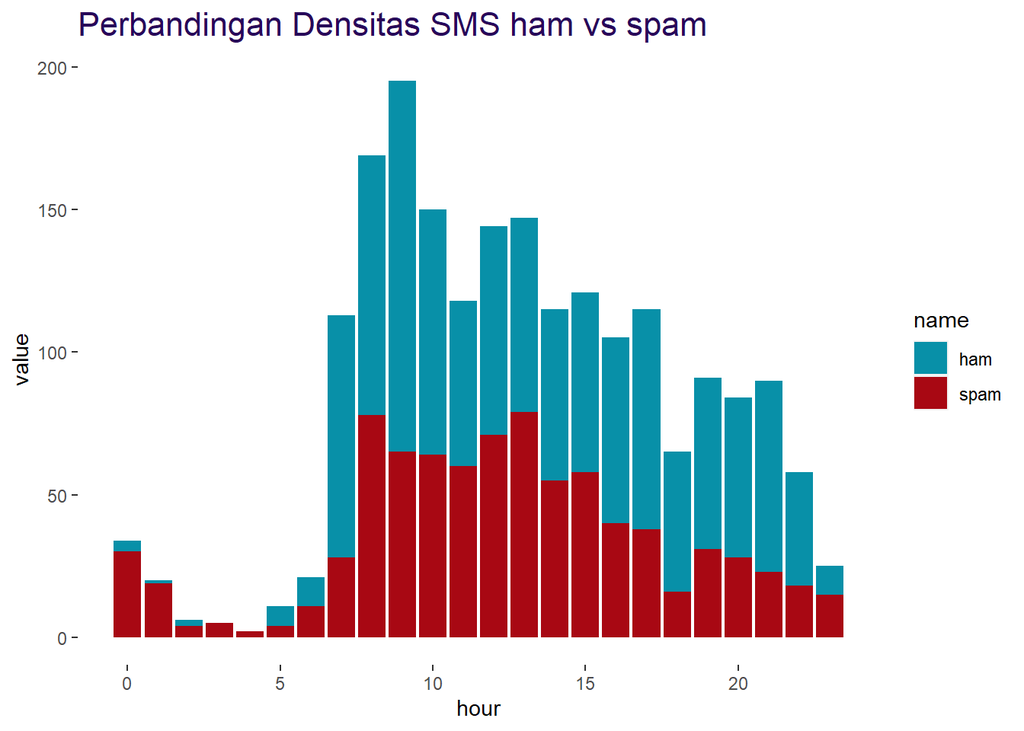

```r
sms %>%
   mutate(hour = hour(datetime)) %>%
   group_by(hour) %>%
   summarise(
      spam = sum(ifelse(status == "spam", 1, 0)),
      ham = sum(ifelse(status == "spam", 0, 1)),
   ) %>%
   ungroup() %>%
   pivot_longer(
      cols=c(ham, spam)
   ) %>%
   ggplot(
      aes(
         x=hour,
         y=value,
         fill=name
      )
   ) +
   geom_col(
      stat="identity"
   ) +
   scale_fill_manual(values=c("#0890a8", "#a80813")) +
   labs(title = "Perbandingan Densitas SMS ham vs spam")+theme(panel.background = element_rect(fill = "white"),
      plot.title = element_text(size = 16, colour = "#280759"),
      plot.background = element_rect(fill = "transparent"))
```

```r
sms <- sms %>%
  select(-datetime)
```

### 2.3.2 Spam & Ham Characteristic

Pemahaman data yang kita gunakan amatlah penting mengingat hal tersebut sangat mempengaruhi proses apa yang akan kita lakukan selanjutnya. Salah satu cara memahami data adalah dengan mengkarakterisasi data. Karena tujuan projek ini adalah sebuah model yang dapat melakukan klasifikasi Spam/Ham pada SMS maka akan tepat bila kita dapat mengkarakterisasi kata atau keyword apa saja yang banyak muncul pada masing-masing status.

Berikut ini adalah kata-kata yang sering muncul pada data train yang digunakan.

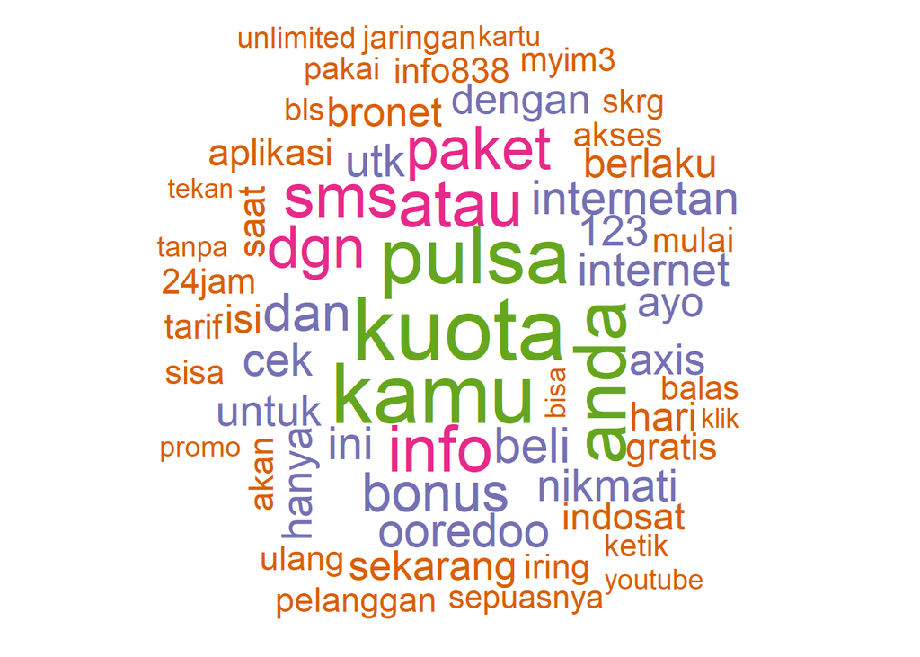

```r
library(wordcloud)
spam <- subset(sms, status == "spam")
wordcloud(spam$text, max.words = 60, colors = brewer.pal(5, "Dark2"), random.order = FALSE)
```

#### 2.3.2.1 Spam Characteristic

```r
sms %>%
   filter(status == "spam") %>%
   tail()
```

|  | text | status |
| --- | --- | --- |
| 837 | Terima kasih kesetiaanmu pada AXIS! BONUS NONTON film SEPUASNYA di Iflix & KZLGAMES tgl 31Mar-1Apr. Hubungi *969# utk aktifkan BONUSnya. Info 838 AFO01A | spam |
| 838 | (AXIS) Kuota utama paket internet kamu telah digunakan seluruhnya. Penggunaan selanjutnya akan dikenakan tarif normal ya. Info838 | spam |
| 839 | PAKET BRONET 24JAM 100MB 1hr Rp3500 kamu sudah tidak aktif. Gunakan terus AXISmu dan temukan promo menarik AXIS lainnya di aplikasi AXISnet. Info838 | spam |
| 840 | PAKET BRONET 4G OWSEM 4GB 30hr Rp38900 kamu sudah tidak aktif. Gunakan terus AXISmu dan temukan promo menarik AXIS lainnya di aplikasi AXISnet. Info838 | spam |
| 841 | AGAR TDK DIBLOKIR,sgr registrasi ulang kartu prabayar Anda.Tlp dan SMS keluar diblokir mulai 1-31 Maret 2018.Ketik ULANG#NIK#No.KK SMS ke 4444.Info 838 | spam |
| 842 | Asik nih!Balas YA, Km bisa menangin:\n- Rp 500 Juta\n- 500gr EMAS\n- Rp 75 JutaGRATIS\nIkutan kuisnya TANPA BIAYA dr AXIS!Balas YA\nInfo: axisnet.id/fantaxis PFF11B | spam |

Data sms yang tergolong ke dalam `SPAM` kebanyakan merupakan pesan iklan, promosi, dan penawaran produk. Kata kunci yang sering muncul antara lain adalah: “bonus”, “menang”, “gratis”.

#### 2.3.2.2 Ham Characteristic

```r
sms %>%
   filter(status == "ham") %>%
   tail()
```

|  | text | status |
| --- | --- | --- |
| 1157 | Telegram code 89789 | ham |
| 1158 | Telegram code 89789 | ham |
| 1159 | Only for Staff! Register w/CIMBNiaga email at shop.samsung .com/id_epp/cimbniaga. Disc upto 30%+Add Disc selected items +0% upto 24mos till 31Mar18. Info 14041 | ham |
| 1160 | Cashback IDR500,000 limited for first 100 cardholders + 0% upto 24 mos with Credit Card at Tory Burch boutiques Jakarta&Surabaya, till 31Mar'18. T&C. Info 14041 | ham |
| 1161 | PERHATIAN!\nKartu AXIS-mu sdh dlm masa peringatan!Registrasikan skrg jg agar tdk terblokir,ke *123*4444# atau telp 838.BONUS kuota 1GB slm 7hr. AAG23C | ham |
| 1162 | Dimana de ? | ham |

Sedangkan yang tergolong ke dalam `HAM` biasanya berhubungan dengan verifikasi, pesan operator, dan pesan pribadi. Kata kunci yang sering muncul antara lain: “dimaana”, “code”.

## 2.4 Data Cleansing

Keterbatasan jumlah karakter yang dimiliki fitur SMS berakibat pada sering terjadinya penyingkattan kata pada pesan yang dikirim. Hal tersebut mudah dipahami manusia namun tidak oleh komputer. Selain itu penggunaan kata yang tidak baku juga seringkali terjadi antara percakapan kita dengan keluarga maupun orang terdekat. Atas dasar hal-hal tersebut `Text Cleansing` menjadi sebuah tahapan yang sangat penting agar kata-kata potensial yang terdapat dalam text pesan dapat dikenali dan di proses dengan baik oleh model dan mesin yang dibuat.

### 2.4.1 Convert to Corpus

```r
sms.corpus <- sms %>%
   # Convert to corpus
   VectorSource() %>%
   VCorpus()
```

### 2.4.2 Text Cleansing

```r
sms.corpus <- sms.corpus %>%
   tm_map(content_transformer(tolower)) %>%
   tm_map(removeNumbers) %>%
   tm_map(removeWords, stopwords("id", source="stopwords-iso")) %>%
   tm_map(removePunctuation) %>%
   tm_map(function(x) { stemDocument(x, language="indonesian") }) %>%
   tm_map(stripWhitespace)
```

### 2.4.3 Convert to Document Term Matrix (DTM)

Untuk dapat membuat model prediksi, tidak dapat digunakan type data text. Dalam kasus ini biasanya data text di konversi menjadi `Document-Term Matrix` (DTM).

```r
sms.dtm <- sms.corpus %>%
   DocumentTermMatrix()
sms.dtm
```

```
#> <<DocumentTermMatrix (documents: 2, terms: 2821)>>
#> Non-/sparse entries: 2822/2820
#> Sparsity           : 50%
#> Maximal term length: 79
#> Weighting          : term frequency (tf)
```

### 2.4.4 Most Frequence Term

Kolom atau kata yang kita punya untuk prediksi sangat banyak. Untuk mengurangi noise (kata-kata yang jarang muncul), kita akan gunakan kata-kata yang cukup sering muncul, setidaknya muncul dalam 20 dokumen (sms). Proses ini juga dapat memangkas waktu training model.

```r
sms.freq <- findFreqTerms(sms.dtm, lowfreq = 20)

sms.dtm <- sms.dtm[,sms.freq]
```

### 2.4.5 Convert to Bernoulli

Nilai pada matrix masih berupa nilai frekuensi. Untuk perhitungan peluang, frekuensi akan diubah menjadi hanya kondisi muncul (1) atau tidak (0). Salah satu caranya dengan menggunakan `Bernoulli Converter`. Berikut contoh transformasi yang dilakukan dengan menggunakan Bernoulli Converter.

```r
bernoulli_conv <- function(x) {
  x <- as.factor(ifelse(x > 0, 1, 0))
  return(x)
}

bernoulli_conv(c(0,1,3))
```

```
#> [1] 0 1 1
#> Levels: 0 1
```

Sekarang kita aplikasikan pada data yang kita miliki.

```r
sms.dtm <- sms.dtm %>%
   apply(MARGIN = 2, FUN = bernoulli_conv)

sms.dtm[1:2, 1:20]
```

```
#>     Terms
#> Docs aja aks aktif aktifkan aplikasi app aspen axi axisnet ayo bala bank beba
#>    1 "1" "1" "1"   "1"      "1"      "1" "1"   "1" "1"     "1" "1"  "1"  "1"
#>    2 "0" "0" "0"   "0"      "0"      "0" "0"   "0" "0"     "0" "0"  "0"  "0"
#>     Terms
#> Docs beli berhasil berita berlaku bersifat biaya blm
#>    1 "1"  "1"      "1"    "1"     "1"      "1"   "1"
#>    2 "0"  "0"      "0"    "0"     "0"      "0"   "0"
```

### 2.4.6 Tokenization Function

Proses tokenization berperan memisahkan sebuah text menjadi pecahan kata yang terpisah dan dapat diindentifikasi satu-persatu.

```r
tokenize_text <- function(x, is_bernoulli = TRUE) {
   data_dtm <- x %>%
      # Convert to corpus
      VectorSource() %>%
      VCorpus() %>%

      # text cleaning
      tm_map(content_transformer(tolower)) %>%
      tm_map(removeNumbers) %>%
      tm_map(removeWords, stopwords("id", source="stopwords-iso")) %>%
      tm_map(removePunctuation) %>%
      tm_map(stemDocument) %>%
      tm_map(stripWhitespace) %>%

      # Convert DTM
      DocumentTermMatrix()

   data_freq <- findFreqTerms(data_dtm, lowfreq = 20)

   if (is_bernoulli) {
      data_dtm[,data_freq] %>%
         apply(MARGIN = 2, FUN = bernoulli_conv) %>%
         return()
   } else {
      data_dtm[,data_freq] %>%
         return()
   }
}
```

## 2.5 Cross Validation

Cleansing data telah selesai dilakukan, selanjutnya dilakukan pembagian data train dan data test dengan proporsi secara berurutan adalah 75% dan 25%.

```r
RNGkind(sample.kind = "Rounding")
set.seed(100)

index <- sample(nrow(sms), nrow(sms)*0.75)

sms_clean <- tokenize_text(sms$text)

data_train_clean <- sms_clean[index,]
data_test_clean <- sms_clean[-index,]

label_train <- sms[index, "status"]
label_test <- sms[-index, "status"]
```

```r
data_train <- sms[index,]
data_test <- sms[-index,]
```

# 3 Model

Pada pemodelan ini akan digunakan dua jenis tipe model agar dapat dilakukan perbandingan, tipe model tersebut antara lain adalah `Naive Bayes` dan `Random Forest`

## 3.1 Naive Bayes

```r
model_nb <- naiveBayes(
   x = data_train_clean,
   y = label_train,
   laplace = 1
)
```

## 3.2 Random Forest

```r
set.seed(521)

ctrl <- trainControl(method="repeatedcv", number = 5, repeats = 3)

model_forest <- train(
   x = data_train_clean,
   y = label_train,
   method = "rf",
   trControl = ctrl
)

saveRDS(model_forest, "spam_forest.RDS") # save model
```

```r
model_forest <- readRDS("spam_forest.RDS")
```

# 4 Predicting

## 4.1 Naive Bayes

```r
sms_pred_naive <- predict(model_nb, newdata = data_test_clean, type="class")
head(sms_pred_naive)
```

```
#> [1] ham  spam spam ham  ham  ham
#> Levels: ham spam
```

## 4.2 Random Forest

```r
sms_pred_rf <- predict(model_forest, newdata = data_test_clean, type="raw")
head(sms_pred_rf)
```

```
#> [1] ham  spam spam ham  spam spam
#> Levels: ham spam
```

# 5 Model Evaluation

Model evaluation dilakukan untuk dapat mengetahui performa masing-masing model yang digunakan untuk prediksi.

## 5.1 Confussion Matrix

Salah satu cara mengevaluasi model yang kita gunakan adalah dengan menggunakan `Confussion Matrix`.

### 5.1.1 Naive Bayes

```r
confusionMatrix(data = sms_pred_naive, reference = label_test, positive = "spam")
```

```
#> Confusion Matrix and Statistics
#>
#>           Reference
#> Prediction ham spam
#>       ham  257   17
#>       spam  27  200
#>
#>                Accuracy : 0.9122
#>                  95% CI : (0.8839, 0.9355)
#>     No Information Rate : 0.5669
#>     P-Value [Acc > NIR] : <0.0000000000000002
#>
#>                   Kappa : 0.8221
#>
#>  Mcnemar's Test P-Value : 0.1748
#>
#>             Sensitivity : 0.9217
#>             Specificity : 0.9049
#>          Pos Pred Value : 0.8811
#>          Neg Pred Value : 0.9380
#>              Prevalence : 0.4331
#>          Detection Rate : 0.3992
#>    Detection Prevalence : 0.4531
#>       Balanced Accuracy : 0.9133
#>
#>        'Positive' Class : spam
#>
```

### 5.1.2 Random Forest

```r
confusionMatrix(data = sms_pred_rf, reference = label_test, positive = "spam")
```

```
#> Confusion Matrix and Statistics
#>
#>           Reference
#> Prediction ham spam
#>       ham  270    6
#>       spam  14  211
#>
#>                Accuracy : 0.9601
#>                  95% CI : (0.939, 0.9754)
#>     No Information Rate : 0.5669
#>     P-Value [Acc > NIR] : <0.0000000000000002
#>
#>                   Kappa : 0.9191
#>
#>  Mcnemar's Test P-Value : 0.1175
#>
#>             Sensitivity : 0.9724
#>             Specificity : 0.9507
#>          Pos Pred Value : 0.9378
#>          Neg Pred Value : 0.9783
#>              Prevalence : 0.4331
#>          Detection Rate : 0.4212
#>    Detection Prevalence : 0.4491
#>       Balanced Accuracy : 0.9615
#>
#>        'Positive' Class : spam
#>
```

Hasil evaluasi menggunakan confussion matrix menunjukkan bahwa akurasi prediksi dengan model `Naive Bayes` adalah **91%** sedangkan prediksi dengan model `Random Forest` menghasilkan akurasi sebesar **96%**.

Karena akurasi yang dihasilkan dengan menggunakan model random forest lebih besar, model inilah yang akn dipilih.

## 5.2 False Prediction

Mencari tahu di bagian mana model kita salah memprediksi.

```r
pred.false <- data_test %>%
   mutate(
      pred.rf = sms_pred_rf,
   ) %>%
   filter(pred.rf != status)
pred.false %>% filter(pred.rf == "spam")
```

| text | status | pred.rf |
| --- | --- | --- |
| PT.Pertamina Bina Medika Menerima Karyawan Baru 2017 Dengan Berbagai Jurusan L/P, Info Lengkap Kunjungi : http://www.recruitment-pertamedika.com | ham | spam |
| LIMITED OFFER! 20% pembelian produk. Berlaku sampai 28 Februari 2017. S&K berlaku. Kunjungi ERHA terdekat. www.erha.co.id | ham | spam |
| Travelingnya happy, terbangnya aman, hotelnya nyaman karena dapat diskon AGODA 7% + Asuransi Gratis 25 Jt! Buruan ke sini http://bit.ly/AktifkanSekarang | ham | spam |
| Selamat Anda mendapatkan perlindungan dari PasarPolis.com. Segera daftar di http://bit.ly/2jY1FnY Gratis tiket nonton utk 500 pendaftar pertama. Info S&K 14041 | ham | spam |
| Langganan Spotify Premium kamu berakhir pd 2017-03-17. Pastikan pulsa kamu cukup utk trs menikmati jutaan musik tanpa iklan. Isi ulang di bit.ly/topupindosat | ham | spam |
| Freedom M Rp 55rb/30hr berhasil dprpanjang sd 17/09/2017 08:05. Nikmati BONUS KUOTA sd 10GB dismua jaringan,APPS TANPA KUOTA,DATA ROLLOVER. Cek http://im3.do/mc | ham | spam |
| MAAF, Paket EXTRA yang Kamu pilih tidak tersedia. Silakan daftar Paket EXTRA atau Paket Lainnya di *123# atau http://mycare.indosatooredoo.com | ham | spam |
| Uber: Anda mendapatkan potongan 50% hingga Rp 5000, untuk 10 perjalanan uberMOTOR Anda. Ayo pesan Uber-mu sekarang! http://t.uber.com/nguber | ham | spam |
| Pulsa tdk ckp utk prpanjang.Utk tetap menggunakan internet.silakan daftar Pkt Internet 50MB Rp5,000/hari dgn Ketik Ya jika setuju atau tarif perKB | ham | spam |
| Plgn 085722688068, +10 KOIN PULSA mu hari ini belum diambil? Hub *858*22# utk Ambil. Sayang lho ga diambil, bisa buat tuker pulsa. Hub *858*22# & Pilih 1 OK. | ham | spam |

[output cut: 4 more lines]

# 6 Model Interpretation

## 6.1 Variable of Importance

```r
caret::varImp(model_forest, 20)$importance %>%
   as.data.frame() %>%
   rownames_to_column() %>%
   arrange(-Overall) %>%
   mutate(rowname = forcats::fct_inorder(rowname))
```

| rowname | Overall |
| --- | --- |
| info | 100.0000000000 |
| grati | 41.6433491722 |
| ooredoo | 39.5316710379 |
| ayo | 34.8855325947 |
| pelanggan | 34.0527428327 |
| ire | 33.6265497447 |
| pulsa | 22.4629709605 |
| isi | 21.5164332563 |
| beli | 20.0545668725 |
| berlaku | 17.5907757279 |

[output cut: 189 more lines]

Dari tabel diatas kita dapat mengetahui bahwa kata yang memiliki bobot pengaruh paling besar adalah `info`. Sebaliknya, kata yang memiliki bobot pengaruh paling kecil ialah `mempengaruhi`

## 6.2 LIME

Local Interpretable Model-agnostic Explanations (LIME) merupakan salah satu teknik interpretasi hasil prediksi yang dilakukan sebuah model. LIME dapat memprediksi model appaun dan menganggapnya sebagai black box model. Pada kesempatan kali ini LIME akan digunakan untuk meninterpretasikan model naive bayes.

```r
model_type.naiveBayes <- function(x){
  return("classification")
}
```

```r
predict_model.naiveBayes <- function(x, newdata, type = "raw") {
    res <- predict(x, newdata, type = "raw") %>% as.data.frame()
    return(res)
}
```

Persipkan data input untuk LIME.

```r
text_train <- data_train$text %>% as.character()
text_test <- data_test$text

explainer <- lime(
   text_train,
   model=model_nb,
   preprocess=tokenize_text
)
```

```r
set.seed(123)
explanation <- explain(
   text_test[1:5],
   explainer = explainer,
   n_labels = 1, # show only 1 label (recommend or not recommend)
   n_features = 5,
   feature_select = "none", # use all terms to explain the model
   single_explanation = F
)
```

Visualisasi LIME

```r
plot_text_explanations(explanation)
```

[interactive chart not shown]

Teks berlabel biru berarti kata support / tingkatkan kemungkinan menjadi SPAM, dengan pengaruh kata promo dan belaku yang paling berpengaruh.

Teks berlabel merah berarti kata tersebut bertentangan / mengurangi probabilitas review menjadi HAM, seperti your, hari atau nasi.

# 7 Submission

## 7.1 Import Data Test

```r
submission <- read.csv("data/data-test.csv")
```

## 7.2 Text Cleansing

```r
submission.clean <- tokenize_text(submission$text)
submission.clean[1:5,1:10]
```

```
#>     Terms
#> Docs aplikasi axi axisnet bala beli berlaku bonus bronet dgn diblokir
#>    1 "0"      "0" "0"     "0"  "1"  "0"     "0"   "0"    "1" "0"
#>    2 "0"      "0" "0"     "0"  "0"  "0"     "0"   "0"    "0" "0"
#>    3 "0"      "0" "0"     "0"  "0"  "0"     "0"   "0"    "0" "0"
#>    4 "0"      "0" "0"     "0"  "0"  "0"     "0"   "0"    "0" "0"
#>    5 "0"      "0" "0"     "0"  "0"  "0"     "1"   "0"    "0" "0"
```

## 7.3 Optimize Data

```r
trimRfPredictor <- function(x, train_data) {
   x %>%
      as.data.frame() %>%
      fncols(colnames(train_data)) %>%
      select(colnames(train_data)) %>%
      mutate_all(as.factor) %>%
      as.matrix.data.frame() %>%
      return()
}
```

```r
fncols <- function(data, cname) {
  add <-cname[!cname%in%names(data)]

  if(length(add)!=0) data[add] <- as.factor("0")
  data
}
```

```r
submission.clean.df <- trimRfPredictor(submission.clean, data_train_clean)
submission.clean.df[1:5,1:20]
```

```
#>      aja aks aktif aktifkan aplikasi app aspen axi axisnet ayo bala bank beba
#> [1,] "0" "0" "0"   "0"      "0"      "0" "0"   "0" "0"     "0" "0"  "0"  "0"
#> [2,] "0" "0" "0"   "0"      "0"      "0" "0"   "0" "0"     "0" "0"  "0"  "0"
#> [3,] "0" "0" "0"   "0"      "0"      "0" "0"   "0" "0"     "0" "0"  "0"  "0"
#> [4,] "0" "0" "0"   "0"      "0"      "0" "0"   "0" "0"     "0" "0"  "0"  "0"
#> [5,] "0" "0" "0"   "0"      "0"      "0" "0"   "0" "0"     "0" "0"  "0"  "0"
#>      beli berhasil berita berlaku bersifat biaya blm
#> [1,] "1"  "0"      "0"    "0"     "0"      "0"   "0"
#> [2,] "0"  "0"      "0"    "0"     "0"      "0"   "0"
#> [3,] "0"  "0"      "0"    "0"     "0"      "0"   "0"
#> [4,] "0"  "0"      "0"    "0"     "0"      "0"   "0"
#> [5,] "0"  "0"      "0"    "0"     "0"      "0"   "0"
```

## 7.4 Predict Submission

### 7.4.1 Naive Bayes

```r
submission.nb <- submission %>%
   select(datetime)
submission.nb$status <- predict(model_nb, newdata = submission.clean.df, type="class")

head(submission.nb)
```

|  | datetime | status |
| --- | --- | --- |
| 1 | 2018-03-01T00:32:00Z | ham |
| 2 | 2018-03-01T08:57:00Z | ham |
| 3 | 2018-03-01T09:15:00Z | spam |
| 4 | 2018-03-01T16:42:00Z | ham |
| 5 | 2018-03-01T17:42:00Z | ham |
| 6 | 2018-03-01T22:04:00Z | ham |

```r
write.csv(submission.nb, "data/submission_nb.csv")
```

### 7.4.2 Random Forest

```r
submission.rf <- submission %>%
   select(datetime)
submission.rf$status <- predict(model_forest, newdata = submission.clean.df, type="raw")

head(submission.rf)
```

|  | datetime | status |
| --- | --- | --- |
| 1 | 2018-03-01T00:32:00Z | spam |
| 2 | 2018-03-01T08:57:00Z | ham |
| 3 | 2018-03-01T09:15:00Z | spam |
| 4 | 2018-03-01T16:42:00Z | spam |
| 5 | 2018-03-01T17:42:00Z | ham |
| 6 | 2018-03-01T22:04:00Z | ham |

```r
write.csv(submission.rf, "data/submission_rf.csv")
```

# 8 Conclusion

Model klasifikasi ini sangat berpotensi untuk pengembangan bisnis online. Dengan automasi dan klasifikasi menggunakan machine learning, sebuah usaha akan sangat dimudahkan dalam memanajemen pesanan maupun keluhan dari pelanggannya.